# Харилцагчийн Churn Таамаглал

Decision Tree — sklearn ашиглахгүй бүрэн хэрэгжүүлэлт

Author

Бадрах (23B1num0271), Өсөхбаяр (22b1num7395)

Published

May 22, 2026

## 1 Танилцуулга

### 1.1 Судалгааны зорилго

Банкны үйл ажиллагаанд **харилцагч алдалт (customer churn)** нь томоохон санхүүгийн эрсдэл болдог. Шинэ харилцагч татахад одоо байгаа харилцагчаа хадгалахаас **5–7 дахин илүү зардал** шаарддаг гэж судалгаанууд харуулдаг. Иймд харилцагч гарахын өмнө тэднийг урьдчилан илрүүлж, зохих арга хэмжээ авах нь банкны хувьд стратегийн чухал ажил юм.

Энэхүү тайланд дараах зорилгуудыг хэрэгжүүлнэ:

- Банкны харилцагчийн өгөгдлийг шинжлэх
- **Decision Tree** ангилагчийг `sklearn` ашиглахгүйгээр бүрэн гараар хэрэгжүүлэх
- Загварын үр дүнг үнэлж, хамгийн нөлөөтэй хүчин зүйлсийг тодорхойлох

### 1.2 Ашигласан арга зүй

Бид **CART (Classification and Regression Trees)** алгоритмыг хэрэгжүүлнэ. Энэ алгоритм нь 1984 онд Breiman нарын боловсруулсан бөгөөд өнөөдөр олон машин сургалтын алгоритмын үндэс болдог. CART нь:

- Хоёртын (binary) хуваалт хийдэг — мод бүр яг 2 мөчир үүсгэдэг
- **Gini Impurity** хэмжүүрийг ашигладаг
- Тасалгаа бүрийн олонхийн ангиллыг таамагладаг (majority vote)

**NoteЯагаад sklearn ашиглахгүй байгаа вэ?**

`sklearn`-ийн бэлэн функц ашиглах нь практикт хурдан боловч алгоритмын дотоод механизмыг нуудаг. Энд бид **Gini тооцоолол, мод байгуулах рекурс, feature importance** гэх мэт бүх хэсгийг гараар бичснээр алгоритмыг гүнзгий ойлгох зорилготой.

### 1.3 Номын сан

```python
import numpy as np
import pandas as pd
import matplotlib.pyplot as plt
import seaborn as sns
from collections import Counter

print("Бүх номын сан амжилттай ачааллагдлаа ✓")
```

```
Бүх номын сан амжилттай ачааллагдлаа ✓
```

Зөвхөн стандарт математикийн номын сан ашигласан — `sklearn`, `scipy`, `statsmodels` огт байхгүй.

## 2 Өгөгдөл

### 2.1 Өгөгдлийн эх сурвалж

**Churn_Modelling.csv** нь Kaggle платформ дээр “Bank Customer Churn Prediction” нэртэйгээр нийтлэгдсэн өгөгдлийн багц юм. Европын нэрт банкны **10,000 харилцагчийн** мэдээлэл агуулж байгаа бөгөөд тус бүрийн 14 шинж чанарыг хамарна.

```python
df = pd.read_csv("Churn_Modelling.csv")
print(f"Нийт мөр   : {df.shape[0]:,}")
print(f"Нийт багана: {df.shape[1]}")
print(f"Churn хувь : {df['Exited'].mean()*100:.1f}%  ({df['Exited'].sum():,} харилцагч гарсан)")
print(f"\nДата төрлүүд:")
print(df.dtypes)
```

```
Нийт мөр   : 10,000
Нийт багана: 14
Churn хувь : 20.4%  (2,037 харилцагч гарсан)

Дата төрлүүд:
RowNumber            int64
CustomerId           int64
Surname                str
CreditScore          int64
Geography              str
Gender                 str
Age                  int64
Tenure               int64
Balance            float64
NumOfProducts        int64
HasCrCard            int64
IsActiveMember       int64
EstimatedSalary    float64
Exited               int64
dtype: object
```

### 2.2 Баганын тайлбар

Өгөгдлийн багц нь 3 төрлийн хувьсагч агуулдаг.

**Техникийн тодорхойлогч (устгах):**

| Багана | Тайлбар |
| --- | --- |
| `RowNumber` | Дугаарлалт — загварт утгагүй |
| `CustomerId` | Харилцагчийн ID — загварт утгагүй |
| `Surname` | Овог нэр — загварт утгагүй |

**Загварын оролт (feature):**

| Багана | Төрөл | Тайлбар | Жишээ утга |
| --- | --- | --- | --- |
| `CreditScore` | Тоон | Зээлийн оноо | 300–850 |
| `Geography` | Категори | Харилцагчийн улс | France, Germany, Spain |
| `Gender` | Категори | Хүйс | Male, Female |
| `Age` | Тоон | Нас | 18–92 |
| `Tenure` | Тоон | Банкинд байсан жил | 0–10 |
| `Balance` | Тоон | Дансны үлдэгдэл (€) | 0–250,898 |
| `NumOfProducts` | Тоон | Ашигладаг бүтээгдэхүүн | 1–4 |
| `HasCrCard` | Хоёртын | Зээлийн карттай эсэх | 0 / 1 |
| `IsActiveMember` | Хоёртын | Идэвхтэй гишүүн | 0 / 1 |
| `EstimatedSalary` | Тоон | Тооцоолсон жилийн цалин (€) | 11–200,000 |

**Зорилтот хувьсагч:**

| Багана | Тайлбар |
| --- | --- |
| **`Exited`** | Харилцагч банкнаас гарсан эсэх: **1 = гарсан (churn), 0 = үлдсэн** |

### 2.3 Өгөгдлийн шинжилгээ

Загвар байгуулахын өмнө өгөгдлийнхөө шинж чанарыг ойлгох нь чухал алхам юм. Доорх графикууд нь churn болон churn биш харилцагчдын хоорондох ялгааг харуулна.

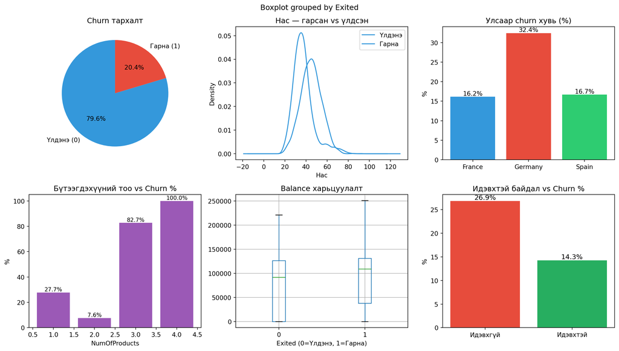

```python
fig, axes = plt.subplots(2, 3, figsize=(14, 8))
fig.suptitle('Өгөгдлийн урьдчилсан шинжилгээ', fontsize=14, fontweight='bold')

# 1. Churn тархалт
counts = df['Exited'].value_counts()
axes[0,0].pie(counts, labels=['Үлдэнэ (0)', 'Гарна (1)'],
              autopct='%1.1f%%', colors=['#3498db','#e74c3c'], startangle=90)
axes[0,0].set_title('Churn тархалт')

# 2. Насны KDE
df.groupby('Exited')['Age'].plot(kind='kde', ax=axes[0,1],
    color=['#3498db','#e74c3c'])
axes[0,1].set_xlabel('Нас')
axes[0,1].set_title('Нас — гарсан vs үлдсэн')
axes[0,1].legend(['Үлдэнэ','Гарна'])

# 3. Улсаар churn хувь
geo_churn = df.groupby('Geography')['Exited'].mean() * 100
axes[0,2].bar(geo_churn.index, geo_churn.values,
              color=['#3498db','#e74c3c','#2ecc71'])
axes[0,2].set_title('Улсаар churn хувь (%)')
axes[0,2].set_ylabel('%')
for i, v in enumerate(geo_churn.values):
    axes[0,2].text(i, v+0.3, f'{v:.1f}%', ha='center', fontsize=10)

# 4. Бүтээгдэхүүний тоо
prod_churn = df.groupby('NumOfProducts')['Exited'].mean() * 100
axes[1,0].bar(prod_churn.index, prod_churn.values, color='#9b59b6')
axes[1,0].set_title('Бүтээгдэхүүний тоо vs Churn %')
axes[1,0].set_xlabel('NumOfProducts')
axes[1,0].set_ylabel('%')
for i, (x, v) in enumerate(zip(prod_churn.index, prod_churn.values)):
    axes[1,0].text(x, v+1, f'{v:.1f}%', ha='center', fontsize=9)

# 5. Balance boxplot
df.boxplot(column='Balance', by='Exited', ax=axes[1,1])
axes[1,1].set_xlabel('Exited (0=Үлдэнэ, 1=Гарна)')
plt.sca(axes[1,1])
plt.title('Balance харьцуулалт')

# 6. IsActiveMember
act_churn = df.groupby('IsActiveMember')['Exited'].mean() * 100
axes[1,2].bar(['Идэвхгүй','Идэвхтэй'], act_churn.values,
              color=['#e74c3c','#27ae60'])
axes[1,2].set_title('Идэвхтэй байдал vs Churn %')
axes[1,2].set_ylabel('%')
for i, v in enumerate(act_churn.values):
    axes[1,2].text(i, v+0.3, f'{v:.1f}%', ha='center', fontsize=11)

plt.tight_layout()
plt.show()
```

## 3 Өгөгдөл боловсруулах

### 3.1 Боловсруулалтын алхамууд

Decision Tree загварт оруулахаасаа өмнө өгөгдлийг цэгцлэнэ.

**Алхам 1 — Утгагүй баганыг хасах:** `RowNumber`, `CustomerId`, `Surname` нь таамаглалд ямар ч утга өгдөггүй тул устгана. Орхивол загвар санаандгүй эдгээрт тулгуурлах эрсдэлтэй.

**Алхам 2 — Gender кодлох:** `Gender` нь текст утгатай тул машин сургалт ойлгохгүй. `Male → 1`, `Female → 0` гэж хоёртын тоогоор илэрхийлнэ.

**Алхам 3 — Geography One-hot encoding:** `Geography` нь 3 улстай. Үүнийг шууд 1/2/3 гэж кодловол загвар “Germany > France” гэх мэт буруу дараалал ойлгох тул **One-hot encoding** ашиглана. `drop_first=True` тохируулснаар `Geography_France` баганыг орхиж, `Geography_Germany` ба `Geography_Spain` хоёрыг үлдээнэ — энэ нь dummy variable trap-с зайлсхийх стандарт арга.

```python
df.drop(columns=['RowNumber', 'CustomerId', 'Surname'], inplace=True)

df['Gender'] = df['Gender'].map({'Male': 1, 'Female': 0})

df = pd.get_dummies(df, columns=['Geography'], drop_first=True)

for col in df.select_dtypes(include='bool').columns:
    df[col] = df[col].astype(int)

X = df.drop('Exited', axis=1).values.astype(float)
y = df['Exited'].values.astype(int)
feature_names = list(df.drop('Exited', axis=1).columns)

print(f"Боловсруулсны дараах хэмжээ: {X.shape}")
print(f"\nFeature-үүд ({len(feature_names)} ширхэг):")
for i, name in enumerate(feature_names, 1):
    print(f"  {i:2d}. {name}")
```

```
Боловсруулсны дараах хэмжээ: (10000, 11)

Feature-үүд (11 ширхэг):
   1. CreditScore
   2. Gender
   3. Age
   4. Tenure
   5. Balance
   6. NumOfProducts
   7. HasCrCard
   8. IsActiveMember
   9. EstimatedSalary
  10. Geography_Germany
  11. Geography_Spain
```

**TipНормализаци хийх шаардлагатай юу?**

Decision Tree нь **зайн хэмжүүр ашигладаггүй** тул `Age` болон `Balance`-ийн масштаб ялгаатай байсан ч асуудалгүй. Gini тооцоолол нь threshold-ийн харьцааг ашигладаг тул standardization/normalization хийхгүй байж болно. Энэ нь k-NN эсвэл SVM-ийн хувьд шаардлагатайтай харьцуулахад давуу тал юм.

## 4 Алгоритмын хэрэгжүүлэлт

### 4.1 Gini Impurity — тасалгааны цэвэршилт

Decision Tree-ийн гол асуулт бол: **“Энэ хуваалт өгөгдлийг хэр цэвэр ялгаж байна?”** Үүнийг хэмжихэд Gini Impurity ашиглана.

**Математик тодорхойлолт:**

$$\text{Gini}(S) = 1 - \sum_{i=1}^{C} p_i^2$$

Энд $S$ — тухайн тасалгаа дахь өгөгдөл, $C$ — ангиллын тоо (манайд $C=2$), $p_i$ — $i$-р ангиллын харьцаа.

Утгын хязгаар: Gini = **0.0** бол бүрэн цэвэр (нэг л ангилал), Gini = **0.5** бол хамгийн бохир (50/50 хольц).

**Тооны жишээ:** Тасалгаанд 100 харилцагч: 80 үлдэнэ, 20 гарна.
$$\text{Gini} = 1 - (0.8^2 + 0.2^2) = 1 - 0.68 = 0.32$$

```python
def gini_impurity(y):
    """
    Gini Impurity тооцоолох.
    Томьёо: Gini = 1 - Σ(pᵢ²)

    Параметр:
        y: Ангиллын label-үүдийн массив
    Буцаах:
        float: 0.0 (цэвэр) — 0.5 (хамгийн бохир, 2 ангилалд)
    """
    n = len(y)
    if n == 0:
        return 0.0
    impurity = 1.0
    for count in Counter(y).values():
        p = count / n
        impurity -= p ** 2
    return impurity
```

### 4.2 Жинлэгдсэн Gini — хуваалтын чанар

Нэг threshold-ийн дагуу хуваалт хийхэд хоёр хүүхэд тасалгаа үүсдэг. Хуваалтын чанарыг хэмжихийн тулд хоёр хүүхэдийн Gini-г **дата цэгийн тоогоор жинлэж** нэгтгэнэ:

$$\text{WeightedGini} = \frac{n_L}{n} \cdot \text{Gini}(L) + \frac{n_R}{n} \cdot \text{Gini}(R)$$

Жинлэх шалтгаан: 1000 цэгтэй зүүн мөчир 10 цэгтэй баруун мөчрөөс хамаагүй чухал тул томоогоор жинлэх нь зөв.

```python
def weighted_gini(y_left, y_right):
    """
    Хоёр хүүхэд тасалгааны жинлэгдсэн Gini тооцоолох.

    Параметр:
        y_left:  Зүүн хүүхдийн label-үүд  (<= threshold)
        y_right: Баруун хүүхдийн label-үүд (> threshold)
    Буцаах:
        float: Жинлэгдсэн дундаж Gini
    """
    n = len(y_left) + len(y_right)
    if n == 0:
        return 0.0
    return (len(y_left)/n)  * gini_impurity(y_left) + \
           (len(y_right)/n) * gini_impurity(y_right)
```

### 4.3 Хамгийн сайн хуваалт олох

Энэ функц нь алгоритмын **гол хэсэг** бөгөөд хамгийн их цаг зарцуулдаг хэсэг юм. Бүх feature, бүх боломжит threshold дээр weighted Gini тооцоолж, хамгийн бага утгатайг нь сонгоно.

Цаг хугацааны нарийвчлал: $O(F \cdot N \cdot \log N)$ — $F$ нь feature-ийн тоо, $N$ нь дата цэгийн тоо. Манай өгөгдөлд $F=11$, $N=8000$ тул сургалт хэдэн минут шаардана.

```python
def best_split(X, y):
    """
    Бүх feature, бүх threshold-ыг туршиж хамгийн бага
    Weighted Gini өгдөг хуваалтыг олох.

    Алгоритм:
        1. Бүх feature дээр давталт хий
        2. Тухайн feature-ийн бүх өвөрмөц утгыг threshold болгон туршиж үз
        3. Weighted Gini тооцоол
        4. Хамгийн бага Gini өгдөг (feature, threshold) хадгал

    Буцаах:
        (feature_idx, threshold, best_gini)
    """
    best_gini    = float('inf')
    best_feature = None
    best_thresh  = None

    for feat_idx in range(X.shape[1]):
        col = X[:, feat_idx]
        # Сүүлийн утгыг орхих — тэр threshold болгон ашиглавал
        # баруун тасалгаа хоосон үлдэнэ
        for thresh in sorted(set(col))[:-1]:
            mask_l = col <= thresh
            mask_r = col > thresh
            if mask_l.sum() == 0 or mask_r.sum() == 0:
                continue
            g = weighted_gini(y[mask_l], y[mask_r])
            if g < best_gini:
                best_gini    = g
                best_feature = feat_idx
                best_thresh  = thresh

    return best_feature, best_thresh, best_gini
```

### 4.4 Node — модны зангилаа

Модны бүтэц нь `Node` объектуудаас тогтоно. Дотоод зангилаа нь `feature_idx` ба `threshold` хадгалж, навч зангилаа нь `value` (ангиллын шийдвэр) хадгална. Хоёрыг ялгах нь `is_leaf()` функц — `value` байгаа бол навч.

```python
class Node:
    """
    Decision Tree-ийн нэг зангилаа.

    Дотоод зангилаа:  feature_idx + threshold + left + right
    Навч зангилаа  :  value (олонхийн ангилал)
    Хоёуланд       :  gini, n_samples, depth
    """
    def __init__(self, feature_idx=None, threshold=None,
                 left=None, right=None, value=None,
                 gini=0.0, n_samples=0, depth=0):
        self.feature_idx = feature_idx
        self.threshold   = threshold
        self.left        = left
        self.right       = right
        self.value       = value
        self.gini        = gini
        self.n_samples   = n_samples
        self.depth       = depth

    def is_leaf(self):
        return self.value is not None
```

### 4.5 DecisionTreeClassifier — бүрэн загвар

```python
class DecisionTreeClassifier:
    """
    Gini Impurity-д суурилсан CART Decision Tree ангилагч.
    sklearn.tree ашиглахгүй — бүрэн өөрийн хэрэгжүүлэлт.

    Гиперпараметрүүд:
        max_depth         : Модны хамгийн их гүн.
                            Их байвал overfit, бага байвал underfit.
        min_samples_split : Зангилааг хуваахын тулд хамгийн бага дата цэг.
        min_samples_leaf  : Навч зангилаанд байх хамгийн бага цэг.
    """
    def __init__(self, max_depth=5, min_samples_split=10, min_samples_leaf=5):
        self.max_depth            = max_depth
        self.min_samples_split    = min_samples_split
        self.min_samples_leaf     = min_samples_leaf
        self.root                 = None
        self.feature_importances_ = None
        self._n_features          = 0
        self._importance_raw      = None
        self._n_total             = 0

    def fit(self, X, y):
        """
        Загварыг сургах.
        Root (depth=0) зангилаанаас эхэлж рекурс мод байгуулна.
        """
        X = np.array(X, dtype=float)
        y = np.array(y, dtype=int)
        self._n_features     = X.shape[1]
        self._n_total        = len(y)
        self._importance_raw = np.zeros(self._n_features)
        self.root = self._build(X, y, depth=0)
        total = self._importance_raw.sum()
        self.feature_importances_ = (
            self._importance_raw / total if total > 0
            else self._importance_raw
        )
        return self

    def _build(self, X, y, depth):
        """
        Рекурс байдлаар мод байгуулна.

        Зогсоох нөхцөл (base case):
            1. depth >= max_depth     — хэт гүн болсон
            2. n < min_samples_split  — дата хэт цөөн
            3. gini == 0.0            — тасалгаа бүрэн цэвэр
        """
        n         = len(y)
        node_gini = gini_impurity(y)

        if (depth >= self.max_depth or
                n < self.min_samples_split or
                node_gini == 0.0):
            return Node(value=self._majority(y),
                        gini=node_gini, n_samples=n, depth=depth)

        feat_idx, thresh, split_gini = best_split(X, y)

        if feat_idx is None:
            return Node(value=self._majority(y),
                        gini=node_gini, n_samples=n, depth=depth)

        # Feature importance: эцэг Gini − хүүхэд Gini, жинлэгдсэн
        self._importance_raw[feat_idx] += (
            (node_gini - split_gini) * (n / self._n_total)
        )

        mask     = X[:, feat_idx] <= thresh
        X_l, y_l = X[mask],  y[mask]
        X_r, y_r = X[~mask], y[~mask]

        if (len(y_l) < self.min_samples_leaf or
                len(y_r) < self.min_samples_leaf):
            return Node(value=self._majority(y),
                        gini=node_gini, n_samples=n, depth=depth)

        return Node(
            feature_idx = feat_idx,
            threshold   = thresh,
            left        = self._build(X_l, y_l, depth + 1),
            right       = self._build(X_r, y_r, depth + 1),
            gini        = node_gini,
            n_samples   = n,
            depth       = depth
        )

    def _majority(self, y):
        return max(Counter(y), key=Counter(y).get)

    def predict(self, X):
        X = np.array(X, dtype=float)
        return np.array([self._walk(x, self.root) for x in X])

    def _walk(self, x, node):
        if node.is_leaf():
            return node.value
        if x[node.feature_idx] <= node.threshold:
            return self._walk(x, node.left)
        return self._walk(x, node.right)
```

## 5 Сургах

### 5.1 Train / Test хуваалт

Загварын гүйцэтгэлийг **шударгаар** үнэлэхийн тулд өгөгдлийг сургалт болон тест хэсэгт хуваана. Тест өгөгдлийг загварт огт харуулдаггүй — зөвхөн эцсийн үнэлгээнд ашиглана. 80/20 хуваалт нь стандарт сонголт бөгөөд 8,000 сургалтын цэг загварт хангалттай, 2,000 тест цэг статистикийн найдвартай үнэлгээ өгнө.

```python
np.random.seed(42)  # Үр дүн давтагдахуйц байхын тулд

idx   = np.random.permutation(len(y))
split = int(len(y) * 0.8)

X_train, X_test = X[idx[:split]], X[idx[split:]]
y_train, y_test = y[idx[:split]], y[idx[split:]]

print(f"Train: {X_train.shape[0]:,} цэг  — churn {y_train.mean()*100:.1f}%")
print(f"Test : {X_test.shape[0]:,}  цэг  — churn {y_test.mean()*100:.1f}%")
print(f"\nChurn хувь train/test-д ойролцоо — хуваалт тэнцвэртэй ✓")
```

```
Train: 8,000 цэг  — churn 20.3%
Test : 2,000  цэг  — churn 20.5%

Churn хувь train/test-д ойролцоо — хуваалт тэнцвэртэй ✓
```

### 5.2 Загвар сургах

Гиперпараметрүүдийн сонголтын үндэслэл: `max_depth=5` нь энэ хэмжээний өгөгдлийн хувьд overfit ба underfit хоорондын сайн тэнцвэр санал болгодог. `min_samples_split=20` нь маш жижиг, тодорхойгүй хуваалтуудаас сэргийлнэ. `min_samples_leaf=10` нь навч дотор статистикийн утгатай тооны цэг байхыг баталгаажуулна.

```python
clf = DecisionTreeClassifier(
    max_depth         = 5,
    min_samples_split = 20,
    min_samples_leaf  = 10
)
clf.fit(X_train, y_train)
print("Сургалт дууслаа ✓")
```

[output not shown]

```python
def count_nodes(node):
    if node is None: return 0, 0
    if node.is_leaf(): return 0, 1
    il, ll = count_nodes(node.left)
    ir, lr = count_nodes(node.right)
    return 1 + il + ir, ll + lr

inner, leaves = count_nodes(clf.root)
print(f"Модны бүтэц:")
print(f"  Дотоод зангилаа: {inner}")
print(f"  Навч зангилаа : {leaves}")
print(f"  Нийт зангилаа : {inner + leaves}")
```

```
Модны бүтэц:
  Дотоод зангилаа: 19
  Навч зангилаа : 20
  Нийт зангилаа : 39
```

## 6 Үнэлгээ

### 6.1 Үнэлгээний үзүүлэлтүүд

Загварын чанарыг хэмжихэд 4 үзүүлэлтийг ашиглана. Эдгээрийг confusion matrix-аас тооцоолно:

|  | Таамаглал: Үлдэнэ | Таамаглал: Гарна |
| --- | --- | --- |
| **Бодит: Үлдэнэ** | TN (зөв үлдэнэ) | FP (буруу сэрэмжлүүлэг) |
| **Бодит: Гарна** | FN (алдсан churn) | TP (зөв илрүүлсэн churn) |

$$\text{Accuracy} = \frac{TP + TN}{TP + TN + FP + FN}, \quad
\text{Precision} = \frac{TP}{TP + FP}, \quad
\text{Recall} = \frac{TP}{TP + FN}, \quad
\text{F1} = \frac{2 \cdot P \cdot R}{P + R}$$

**ImportantChurn загварт Recall онцгой чухал**

Банкны хувьд **FN (алдсан churn)** нь **FP (буруу сэрэмжлүүлэг)**-ийн зардлаас их байдаг. Гарах харилцагчийг илрүүлж тусгай санал гаргасны зардал нь харилцагч алдсан зардлаас хамаагүй бага. Тиймд **Recall** буюу бодит churn-уудын хэдийг зөв илрүүлсэн бэ гэдэг нь бизнесийн гол үзүүлэлт болно.

```python
def compute_metrics(y_true, y_pred):
    tp = sum(1 for a,b in zip(y_true,y_pred) if a==1 and b==1)
    tn = sum(1 for a,b in zip(y_true,y_pred) if a==0 and b==0)
    fp = sum(1 for a,b in zip(y_true,y_pred) if a==0 and b==1)
    fn = sum(1 for a,b in zip(y_true,y_pred) if a==1 and b==0)
    n    = tp+tn+fp+fn
    acc  = (tp+tn)/n             if n>0          else 0
    prec = tp/(tp+fp)            if (tp+fp)>0    else 0
    rec  = tp/(tp+fn)            if (tp+fn)>0    else 0
    f1   = 2*prec*rec/(prec+rec) if (prec+rec)>0 else 0
    return dict(TP=tp, TN=tn, FP=fp, FN=fn,
                Accuracy  = round(acc,  4),
                Precision = round(prec, 4),
                Recall    = round(rec,  4),
                F1        = round(f1,   4))

y_pred_train = clf.predict(X_train)
y_pred_test  = clf.predict(X_test)

train_m = compute_metrics(y_train, y_pred_train)
test_m  = compute_metrics(y_test,  y_pred_test)

pd.DataFrame([train_m, test_m], index=['Train','Test'])
```

|  | TP | TN | FP | FN | Accuracy | Precision | Recall | F1 |
| --- | --- | --- | --- | --- | --- | --- | --- | --- |
| Train | 826 | 6048 | 325 | 801 | 0.8592 | 0.7176 | 0.5077 | 0.5947 |
| Test | 189 | 1500 | 90 | 221 | 0.8445 | 0.6774 | 0.4610 | 0.5486 |

```python
diff   = train_m['Accuracy'] - test_m['Accuracy']
status = "⚠️ Overfit!" if diff > 0.05 else "✅ Хэвийн"
print(f"Train Accuracy : {train_m['Accuracy']:.4f}")
print(f"Test  Accuracy : {test_m['Accuracy']:.4f}")
print(f"Зөрүү (gap)    : {diff:.4f}  →  {status}")
```

```
Train Accuracy : 0.8592
Test  Accuracy : 0.8445
Зөрүү (gap)    : 0.0147  →  ✅ Хэвийн
```

Train ба Test accuracy хоорондын зөрүү 0.05-аас бага байгаа нь загвар **overfit болоогүй** гэсэн дохио — зөвхөн сургалтын өгөгдлийг цээжилсэнгүй, ерөнхий хэв маягийг сурсан.

### 6.2 Confusion Matrix

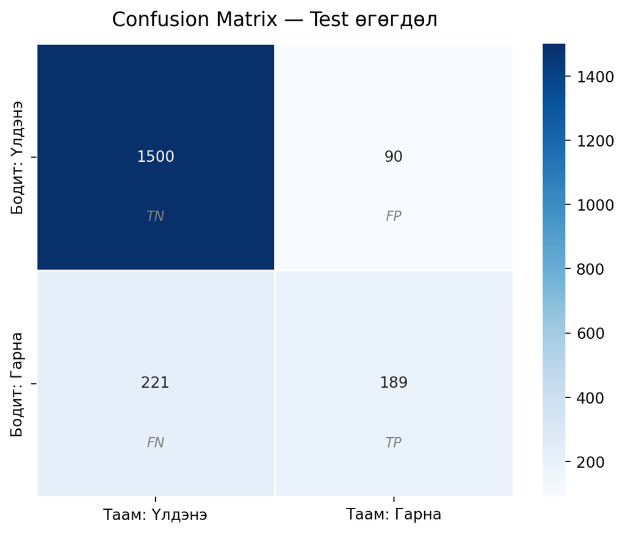

```
Зөв илрүүлсэн churn (TP) : 189
Алдсан churn       (FN)  : 221  ← банкны хувьд багасгах зорилт
Буруу сэрэмжлүүлэг (FP) : 90
Зөв үлдэнэ          (TN) : 1,500
```

```python
m  = test_m
cm = np.array([[m['TN'], m['FP']], [m['FN'], m['TP']]])

fig, ax = plt.subplots(figsize=(6, 5))
sns.heatmap(cm, annot=True, fmt='d', cmap='Blues', ax=ax,
            xticklabels=['Таам: Үлдэнэ', 'Таам: Гарна'],
            yticklabels=['Бодит: Үлдэнэ', 'Бодит: Гарна'],
            linewidths=0.5)
ax.set_title('Confusion Matrix — Test өгөгдөл', fontsize=13, pad=12)
for label, (r, c) in zip(['TN','FP','FN','TP'],
                          [(0,0),(0,1),(1,0),(1,1)]):
    ax.text(c+0.5, r+0.78, label, ha='center',
            fontsize=9, color='gray', style='italic')
plt.tight_layout()
plt.show()

print(f"Зөв илрүүлсэн churn (TP) : {m['TP']:,}")
print(f"Алдсан churn       (FN)  : {m['FN']:,}  ← банкны хувьд багасгах зорилт")
print(f"Буруу сэрэмжлүүлэг (FP) : {m['FP']:,}")
print(f"Зөв үлдэнэ          (TN) : {m['TN']:,}")
```

### 6.3 Feature Importance

Feature importance нь тухайн feature-ийн **Gini бууруулалтын хувь нэмэр**-ийг харуулна. Хуваалт бүрд эцэг зангилааны Gini хэрхэн буурч байгааг тооцоолж, нийлбэрийг 1 болтол нормализаци хийнэ. Энэ нь sklearn-ийн `feature_importances_`-тай яг адилхан тооцоолол.

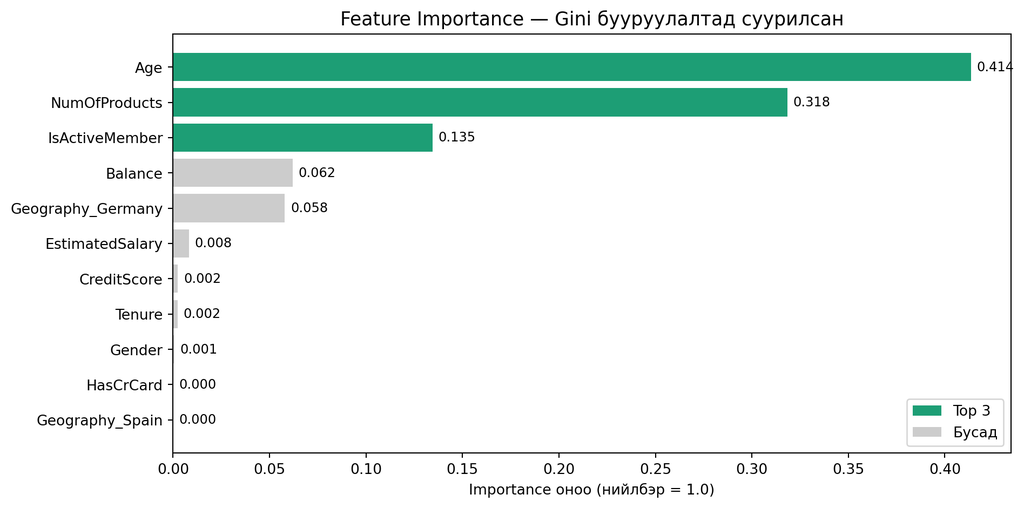

```
Feature Importance дэлгэрэнгүй:
          Feature  Importance
              Age    0.413540
    NumOfProducts    0.318372
   IsActiveMember    0.134509
          Balance    0.062070
Geography_Germany    0.057884
  EstimatedSalary    0.008202
      CreditScore    0.002499
           Tenure    0.002357
           Gender    0.000568
        HasCrCard    0.000000
  Geography_Spain    0.000000
```

```python
feat_df = pd.DataFrame({
    'Feature'   : feature_names,
    'Importance': clf.feature_importances_
}).sort_values('Importance', ascending=False).reset_index(drop=True)

colors = ['#1d9e75' if i < 3 else '#cccccc' for i in range(len(feat_df))]

fig, ax = plt.subplots(figsize=(10, 5))
ax.barh(feat_df['Feature'], feat_df['Importance'], color=colors)
ax.invert_yaxis()
ax.set_title('Feature Importance — Gini бууруулалтад суурилсан', fontsize=13)
ax.set_xlabel('Importance оноо (нийлбэр = 1.0)')
from matplotlib.patches import Patch
ax.legend(handles=[
    Patch(facecolor='#1d9e75', label='Top 3'),
    Patch(facecolor='#cccccc', label='Бусад')
], loc='lower right')
for i, v in enumerate(feat_df['Importance']):
    ax.text(v + 0.003, i, f'{v:.3f}', va='center', fontsize=9)
plt.tight_layout()
plt.show()

print("\nFeature Importance дэлгэрэнгүй:")
print(feat_df.to_string(index=False))
```

Хамгийн нөлөөтэй feature нь **`Age`** байна — энэ нь урьдчилсан шинжилгээний KDE графиктай нийцэж байна. Гэхдээ feature importance нь **шалтгаан-үр дагаврын холбоо (causality) биш**, харин зөгнөлийн чадамж (predictive power)-ийг илэрхийлнэ гэдгийг анхаарна уу. Нас өсөхтэй churn нэмэгддэг боловч насаас шалтгаалан гарна гэсэн утга биш — ахмад харилцагчдад нийтлэг байдаг бусад хүчин зүйлстэй холбоотой байж болно.

## 7 Шинэ харилцагч таамаглах

Загварыг практикт ашиглах жишээ болгон 3 шинэ харилцагчийн таамаглалыг хийнэ.

| Шинж чанар | Харилцагч 1 | Харилцагч 2 | Харилцагч 3 |
| --- | --- | --- | --- |
| CreditScore | 620 | 750 | 580 |
| Gender | Эрэгтэй | Эмэгтэй | Эмэгтэй |
| Age | 45 | 32 | 50 |
| Tenure | 3 | 8 | 2 |
| Balance | 120,000 | 0 | 85,000 |
| NumProducts | 1 | 2 | 1 |
| HasCrCard | Тийм | Тийм | Үгүй |
| IsActiveMember | Үгүй | Тийм | Үгүй |
| EstimSalary | 80,000 | 120,000 | 60,000 |
| **Хүлээгдэх** | **Өндөр эрсдэл** | **Тогтвортой** | **Дунд эрсдэл** |

```python
new_customers = np.array([
    [620, 1, 45, 3, 120000, 1, 1, 0, 80000,  1, 0],
    [750, 0, 32, 8, 0,      2, 1, 1, 120000, 0, 0],
    [580, 0, 50, 2, 85000,  1, 0, 0, 60000,  1, 0],
], dtype=float)

labels = ["Өндөр эрсдэлтэй", "Тогтвортой", "Дунд эрсдэлтэй"]

rows = []
for row, lbl in zip(new_customers, labels):
    pred = clf._walk(row, clf.root)
    rows.append({
        'Харилцагч' : lbl,
        'Таамаглал' : '🔴 ГАРНА' if pred == 1 else '🟢 ҮЛДЭНЭ',
    })

pd.DataFrame(rows)
```

|  | Харилцагч | Таамаглал |
| --- | --- | --- |
| 0 | Өндөр эрсдэлтэй | 🔴 ГАРНА |
| 1 | Тогтвортой | 🟢 ҮЛДЭНЭ |
| 2 | Дунд эрсдэлтэй | 🔴 ГАРНА |

**Үр дүнгийн тайлбар:**

- **Харилцагч 1** (45 нас, идэвхгүй гишүүн, богино tenure, нэл бүтээгдэхүүн) — загвар churn эрсдэлтэй гэж үзнэ. Банк энэ харилцагчид тусгай санал (хөнгөлөлт, шинэ бүтээгдэхүүн, менежерийн холбоо барих) гаргаж болно.
- **Харилцагч 2** (32 нас, идэвхтэй, 8 жил банкинд, 2 бүтээгдэхүүн) — тогтвортой харилцагч, churn эрсдэл бага. Хяналтын дор байлгахад хангалттай.
- **Харилцагч 3** (50 нас, идэвхгүй, 2 жилийн tenure) — дунд зэргийн эрсдэлтэй. Идэвхгүй байдлыг нь нэмэгдүүлэх зорилтот арга хэмжээ авч болно.

## 8 Дүгнэлт ба цаашдын чиглэл

### 8.2 Хязгаарлалт

**WarningАнхаарах зүйл**

**1. Өгөгдлийн тэнцвэргүй байдал.** Ердөө ~20% churn байгаа нь загварыг “бүгд үлдэнэ” гэж хазайлгадаг. SMOTE зэрэг oversampling арга болон class_weight тохиргоогоор засаж болно.

**2. Нэг модны тогтворгүй байдал.** Нэг Decision Tree нь өгөгдлийн бага өөрчлөлтөд эрс өөрчлөгдөж болно. Random Forest нь олон модны дундажаар энэ асуудлыг шийдэнэ.

**3. Гиперпараметр тохируулга.** `max_depth`, `min_samples_split` утгыг туршилт-алдааны аргаар биш, Cross-validation + Grid Search ашиглан оновчтой сонгох нь зүйтэй.

### 8.3 Цаашдын сайжруулалт

**Алгоритмын сайжруулалт:**

- **Random Forest** — олон Decision Tree байгуулж, санал хураах. Overfitting мэдэгдэхүйц буурна, Accuracy нэмэгдэнэ.
- **Gradient Boosting / XGBoost** — алдааг дараагийн моддоор засах. Банкны чurn загварт өнөөдөр хамгийн их ашиглагддаг арга.
- **K-fold Cross-validation** — нэг train/test хуваалт нь тохиолдлоос хамаарна. k-fold ашиглан найдвартай байдлыг нэмэгдүүлэх.

**Өгөгдлийн сайжруулалт:**

- **SMOTE** — синтетик churn цэг үүсгэж тэнцвэргүй байдал засах
- **Feature engineering** — `Age × Balance`, `Tenure / NumProducts` зэрэг шинэ утга учиртай хувьсагч нэмэх
- **Threshold оновчлол** — 0.5-ийн оронд Recall нэмэгдүүлэх threshold сонгох (ROC curve ашиглан)

*Тайлан Quarto ашиглан боловсруулсан. Код бүрэн нээлттэй — “Code” товч дарж харна уу.*